# Detecção de fraude em transações de cartão de crédito

#### Objetivo: Desenvolver um modelo de detecção de fraude em transações de cartão de crédito, capaz de identificar transações fraudulentas com base em atributos relevantes.

#### Dados: Transações de cartão de crédito realizadas durante 2 dias, onde algumas são fraudulentas e outras são legítimas.

## Bibliotecas utilizadas

```python
import pandas as pd
import seaborn as sns
import matplotlib.pyplot as plt
import optuna
from sklearn.preprocessing import RobustScaler
from sklearn.model_selection import train_test_split, cross_val_score
from sklearn.utils import resample
from imblearn.over_sampling import SMOTE
from sklearn.model_selection import StratifiedKFold
from sklearn.metrics import recall_score, classification_report, confusion_matrix

# Modelos
from sklearn.linear_model import LogisticRegression
from sklearn.svm import SVC
from sklearn.naive_bayes import GaussianNB
from sklearn.ensemble import RandomForestClassifier
from sklearn.ensemble import GradientBoostingClassifier
from xgboost import XGBClassifier
from catboost import CatBoostClassifier
from lightgbm import LGBMClassifier
```

## Dicionário dos dados

#### Com base na descrição do Kaggle: https://www.kaggle.com/datasets/mlg-ulb/creditcardfraud/

- **Time**: Segundos decorridos entre esta transação e a primeira transação no conjunto de dados.
- **V1 - V28**: Variáveis afetadas pela aplicação do método de redução de dimensionalidade PCA, aplicado para proteger as informações sensíveis das variáveis.
- **Amount**: Valor da transação.
- **Class**: Classificação da transação, sendo **1** para fraudulenta e **0** para não fraudulenta.

```python
df_original = pd.read_csv('./creditcard.csv')

df_original
```

|  | Time | V1 | V2 | V3 | V4 | V5 | V6 | V7 | V8 | V9 | ... | V21 | V22 | V23 | V24 | V25 | V26 | V27 | V28 | Amount | Class |
| --- | --- | --- | --- | --- | --- | --- | --- | --- | --- | --- | --- | --- | --- | --- | --- | --- | --- | --- | --- | --- | --- |
| 0 | 0.0 | -1.359807 | -0.072781 | 2.536347 | 1.378155 | -0.338321 | 0.462388 | 0.239599 | 0.098698 | 0.363787 | ... | -0.018307 | 0.277838 | -0.110474 | 0.066928 | 0.128539 | -0.189115 | 0.133558 | -0.021053 | 149.62 | 0 |
| 1 | 0.0 | 1.191857 | 0.266151 | 0.166480 | 0.448154 | 0.060018 | -0.082361 | -0.078803 | 0.085102 | -0.255425 | ... | -0.225775 | -0.638672 | 0.101288 | -0.339846 | 0.167170 | 0.125895 | -0.008983 | 0.014724 | 2.69 | 0 |
| 2 | 1.0 | -1.358354 | -1.340163 | 1.773209 | 0.379780 | -0.503198 | 1.800499 | 0.791461 | 0.247676 | -1.514654 | ... | 0.247998 | 0.771679 | 0.909412 | -0.689281 | -0.327642 | -0.139097 | -0.055353 | -0.059752 | 378.66 | 0 |
| 3 | 1.0 | -0.966272 | -0.185226 | 1.792993 | -0.863291 | -0.010309 | 1.247203 | 0.237609 | 0.377436 | -1.387024 | ... | -0.108300 | 0.005274 | -0.190321 | -1.175575 | 0.647376 | -0.221929 | 0.062723 | 0.061458 | 123.50 | 0 |
| 4 | 2.0 | -1.158233 | 0.877737 | 1.548718 | 0.403034 | -0.407193 | 0.095921 | 0.592941 | -0.270533 | 0.817739 | ... | -0.009431 | 0.798278 | -0.137458 | 0.141267 | -0.206010 | 0.502292 | 0.219422 | 0.215153 | 69.99 | 0 |
| ... | ... | ... | ... | ... | ... | ... | ... | ... | ... | ... | ... | ... | ... | ... | ... | ... | ... | ... | ... | ... | ... |
| 284802 | 172786.0 | -11.881118 | 10.071785 | -9.834783 | -2.066656 | -5.364473 | -2.606837 | -4.918215 | 7.305334 | 1.914428 | ... | 0.213454 | 0.111864 | 1.014480 | -0.509348 | 1.436807 | 0.250034 | 0.943651 | 0.823731 | 0.77 | 0 |
| 284803 | 172787.0 | -0.732789 | -0.055080 | 2.035030 | -0.738589 | 0.868229 | 1.058415 | 0.024330 | 0.294869 | 0.584800 | ... | 0.214205 | 0.924384 | 0.012463 | -1.016226 | -0.606624 | -0.395255 | 0.068472 | -0.053527 | 24.79 | 0 |
| 284804 | 172788.0 | 1.919565 | -0.301254 | -3.249640 | -0.557828 | 2.630515 | 3.031260 | -0.296827 | 0.708417 | 0.432454 | ... | 0.232045 | 0.578229 | -0.037501 | 0.640134 | 0.265745 | -0.087371 | 0.004455 | -0.026561 | 67.88 | 0 |
| 284805 | 172788.0 | -0.240440 | 0.530483 | 0.702510 | 0.689799 | -0.377961 | 0.623708 | -0.686180 | 0.679145 | 0.392087 | ... | 0.265245 | 0.800049 | -0.163298 | 0.123205 | -0.569159 | 0.546668 | 0.108821 | 0.104533 | 10.00 | 0 |
| 284806 | 172792.0 | -0.533413 | -0.189733 | 0.703337 | -0.506271 | -0.012546 | -0.649617 | 1.577006 | -0.414650 | 0.486180 | ... | 0.261057 | 0.643078 | 0.376777 | 0.008797 | -0.473649 | -0.818267 | -0.002415 | 0.013649 | 217.00 | 0 |

284807 rows × 31 columns

## Análise exploratória

- Não existem valores nulos em nenhuma das colunas.
- As variáveis V1 a V28 estão dentro de uma escala, já que o método de redução de dimensionalidade PCA foi aplicado.
- Existem transações com valores que podem ser considerados outliers.
- A média dos valores das transações é de **US\$ 88.34**, mas essa média é afetada pelos outliers presentes nessa variável.
- O maior valor transacionado para 99% dos registros é de US\$ 1017.97, apesar do valor máximo para todas as transações ser de US\$ 25691.16.
- Do total de transações, **99.83%** são legítimas e somente **0.17%** são fraudes.
- Apesar da média de valores nas transações ser maior na base de fraudes, os maiores valores de transações estão presentes na base sem fraudes.

```python
df_original.describe(percentiles=[0.25, 0.5, 0.75, 0.90, 0.99])
```

|  | Time | V1 | V2 | V3 | V4 | V5 | V6 | V7 | V8 | V9 | ... | V21 | V22 | V23 | V24 | V25 | V26 | V27 | V28 | Amount | Class |
| --- | --- | --- | --- | --- | --- | --- | --- | --- | --- | --- | --- | --- | --- | --- | --- | --- | --- | --- | --- | --- | --- |
| count | 284807.000000 | 2.848070e+05 | 2.848070e+05 | 2.848070e+05 | 2.848070e+05 | 2.848070e+05 | 2.848070e+05 | 2.848070e+05 | 2.848070e+05 | 2.848070e+05 | ... | 2.848070e+05 | 2.848070e+05 | 2.848070e+05 | 2.848070e+05 | 2.848070e+05 | 2.848070e+05 | 2.848070e+05 | 2.848070e+05 | 284807.000000 | 284807.000000 |
| mean | 94813.859575 | 1.168375e-15 | 3.416908e-16 | -1.379537e-15 | 2.074095e-15 | 9.604066e-16 | 1.487313e-15 | -5.556467e-16 | 1.213481e-16 | -2.406331e-15 | ... | 1.654067e-16 | -3.568593e-16 | 2.578648e-16 | 4.473266e-15 | 5.340915e-16 | 1.683437e-15 | -3.660091e-16 | -1.227390e-16 | 88.349619 | 0.001727 |
| std | 47488.145955 | 1.958696e+00 | 1.651309e+00 | 1.516255e+00 | 1.415869e+00 | 1.380247e+00 | 1.332271e+00 | 1.237094e+00 | 1.194353e+00 | 1.098632e+00 | ... | 7.345240e-01 | 7.257016e-01 | 6.244603e-01 | 6.056471e-01 | 5.212781e-01 | 4.822270e-01 | 4.036325e-01 | 3.300833e-01 | 250.120109 | 0.041527 |
| min | 0.000000 | -5.640751e+01 | -7.271573e+01 | -4.832559e+01 | -5.683171e+00 | -1.137433e+02 | -2.616051e+01 | -4.355724e+01 | -7.321672e+01 | -1.343407e+01 | ... | -3.483038e+01 | -1.093314e+01 | -4.480774e+01 | -2.836627e+00 | -1.029540e+01 | -2.604551e+00 | -2.256568e+01 | -1.543008e+01 | 0.000000 | 0.000000 |
| 25% | 54201.500000 | -9.203734e-01 | -5.985499e-01 | -8.903648e-01 | -8.486401e-01 | -6.915971e-01 | -7.682956e-01 | -5.540759e-01 | -2.086297e-01 | -6.430976e-01 | ... | -2.283949e-01 | -5.423504e-01 | -1.618463e-01 | -3.545861e-01 | -3.171451e-01 | -3.269839e-01 | -7.083953e-02 | -5.295979e-02 | 5.600000 | 0.000000 |
| 50% | 84692.000000 | 1.810880e-02 | 6.548556e-02 | 1.798463e-01 | -1.984653e-02 | -5.433583e-02 | -2.741871e-01 | 4.010308e-02 | 2.235804e-02 | -5.142873e-02 | ... | -2.945017e-02 | 6.781943e-03 | -1.119293e-02 | 4.097606e-02 | 1.659350e-02 | -5.213911e-02 | 1.342146e-03 | 1.124383e-02 | 22.000000 | 0.000000 |
| 75% | 139320.500000 | 1.315642e+00 | 8.037239e-01 | 1.027196e+00 | 7.433413e-01 | 6.119264e-01 | 3.985649e-01 | 5.704361e-01 | 3.273459e-01 | 5.971390e-01 | ... | 1.863772e-01 | 5.285536e-01 | 1.476421e-01 | 4.395266e-01 | 3.507156e-01 | 2.409522e-01 | 9.104512e-02 | 7.827995e-02 | 77.165000 | 0.000000 |
| 90% | 157640.400000 | 2.015409e+00 | 1.326635e+00 | 1.676173e+00 | 1.482807e+00 | 1.407893e+00 | 1.509365e+00 | 1.039387e+00 | 7.693811e-01 | 1.301671e+00 | ... | 3.761555e-01 | 9.148826e-01 | 3.392860e-01 | 7.054036e-01 | 6.009027e-01 | 6.889469e-01 | 2.653679e-01 | 1.799362e-01 | 203.000000 | 0.000000 |
| 99% | 170560.940000 | 2.237130e+00 | 3.801811e+00 | 2.728434e+00 | 4.248032e+00 | 3.424903e+00 | 4.200085e+00 | 2.696205e+00 | 2.075973e+00 | 2.986773e+00 | ... | 1.931852e+00 | 1.530152e+00 | 1.508703e+00 | 1.063748e+00 | 1.203955e+00 | 1.158698e+00 | 9.313604e-01 | 5.411264e-01 | 1017.970000 | 0.000000 |
| max | 172792.000000 | 2.454930e+00 | 2.205773e+01 | 9.382558e+00 | 1.687534e+01 | 3.480167e+01 | 7.330163e+01 | 1.205895e+02 | 2.000721e+01 | 1.559499e+01 | ... | 2.720284e+01 | 1.050309e+01 | 2.252841e+01 | 4.584549e+00 | 7.519589e+00 | 3.517346e+00 | 3.161220e+01 | 3.384781e+01 | 25691.160000 | 1.000000 |

10 rows × 31 columns

### Contagem de nulos

```python
df_original.isna().sum().to_frame().rename(columns={0:'Contagem de nulos'})
```

|  | Contagem de nulos |
| --- | --- |
| Time | 0 |
| V1 | 0 |
| V2 | 0 |
| V3 | 0 |
| V4 | 0 |
| V5 | 0 |
| V6 | 0 |
| V7 | 0 |
| V8 | 0 |
| V9 | 0 |
| V10 | 0 |
| V11 | 0 |
| V12 | 0 |
| V13 | 0 |
| V14 | 0 |
| V15 | 0 |
| V16 | 0 |
| V17 | 0 |
| V18 | 0 |
| V19 | 0 |
| V20 | 0 |
| V21 | 0 |
| V22 | 0 |
| V23 | 0 |
| V24 | 0 |
| V25 | 0 |
| V26 | 0 |
| V27 | 0 |
| V28 | 0 |
| Amount | 0 |
| Class | 0 |

### Analisando com base na variável de fraude

```python
df_fraude = df_original[df_original['Class']==1]
df_nao_fraude = df_original[df_original['Class']==0]

display(f'Percentual de presença de transações fraudulentas: {round((len(df_fraude)/len(df_original))*100, 2)}%')
display(f'Percentual de presença de transações legítimas: {round((len(df_nao_fraude)/len(df_original))*100, 2)}%')

display(df_fraude)
display(df_nao_fraude)
```

```
'Percentual de presença de transações fraudulentas: 0.17%'
```

```
'Percentual de presença de transações legítimas: 99.83%'
```

|  | Time | V1 | V2 | V3 | V4 | V5 | V6 | V7 | V8 | V9 | ... | V21 | V22 | V23 | V24 | V25 | V26 | V27 | V28 | Amount | Class |
| --- | --- | --- | --- | --- | --- | --- | --- | --- | --- | --- | --- | --- | --- | --- | --- | --- | --- | --- | --- | --- | --- |
| 541 | 406.0 | -2.312227 | 1.951992 | -1.609851 | 3.997906 | -0.522188 | -1.426545 | -2.537387 | 1.391657 | -2.770089 | ... | 0.517232 | -0.035049 | -0.465211 | 0.320198 | 0.044519 | 0.177840 | 0.261145 | -0.143276 | 0.00 | 1 |
| 623 | 472.0 | -3.043541 | -3.157307 | 1.088463 | 2.288644 | 1.359805 | -1.064823 | 0.325574 | -0.067794 | -0.270953 | ... | 0.661696 | 0.435477 | 1.375966 | -0.293803 | 0.279798 | -0.145362 | -0.252773 | 0.035764 | 529.00 | 1 |
| 4920 | 4462.0 | -2.303350 | 1.759247 | -0.359745 | 2.330243 | -0.821628 | -0.075788 | 0.562320 | -0.399147 | -0.238253 | ... | -0.294166 | -0.932391 | 0.172726 | -0.087330 | -0.156114 | -0.542628 | 0.039566 | -0.153029 | 239.93 | 1 |
| 6108 | 6986.0 | -4.397974 | 1.358367 | -2.592844 | 2.679787 | -1.128131 | -1.706536 | -3.496197 | -0.248778 | -0.247768 | ... | 0.573574 | 0.176968 | -0.436207 | -0.053502 | 0.252405 | -0.657488 | -0.827136 | 0.849573 | 59.00 | 1 |
| 6329 | 7519.0 | 1.234235 | 3.019740 | -4.304597 | 4.732795 | 3.624201 | -1.357746 | 1.713445 | -0.496358 | -1.282858 | ... | -0.379068 | -0.704181 | -0.656805 | -1.632653 | 1.488901 | 0.566797 | -0.010016 | 0.146793 | 1.00 | 1 |
| ... | ... | ... | ... | ... | ... | ... | ... | ... | ... | ... | ... | ... | ... | ... | ... | ... | ... | ... | ... | ... | ... |
| 279863 | 169142.0 | -1.927883 | 1.125653 | -4.518331 | 1.749293 | -1.566487 | -2.010494 | -0.882850 | 0.697211 | -2.064945 | ... | 0.778584 | -0.319189 | 0.639419 | -0.294885 | 0.537503 | 0.788395 | 0.292680 | 0.147968 | 390.00 | 1 |
| 280143 | 169347.0 | 1.378559 | 1.289381 | -5.004247 | 1.411850 | 0.442581 | -1.326536 | -1.413170 | 0.248525 | -1.127396 | ... | 0.370612 | 0.028234 | -0.145640 | -0.081049 | 0.521875 | 0.739467 | 0.389152 | 0.186637 | 0.76 | 1 |
| 280149 | 169351.0 | -0.676143 | 1.126366 | -2.213700 | 0.468308 | -1.120541 | -0.003346 | -2.234739 | 1.210158 | -0.652250 | ... | 0.751826 | 0.834108 | 0.190944 | 0.032070 | -0.739695 | 0.471111 | 0.385107 | 0.194361 | 77.89 | 1 |
| 281144 | 169966.0 | -3.113832 | 0.585864 | -5.399730 | 1.817092 | -0.840618 | -2.943548 | -2.208002 | 1.058733 | -1.632333 | ... | 0.583276 | -0.269209 | -0.456108 | -0.183659 | -0.328168 | 0.606116 | 0.884876 | -0.253700 | 245.00 | 1 |
| 281674 | 170348.0 | 1.991976 | 0.158476 | -2.583441 | 0.408670 | 1.151147 | -0.096695 | 0.223050 | -0.068384 | 0.577829 | ... | -0.164350 | -0.295135 | -0.072173 | -0.450261 | 0.313267 | -0.289617 | 0.002988 | -0.015309 | 42.53 | 1 |

492 rows × 31 columns

|  | Time | V1 | V2 | V3 | V4 | V5 | V6 | V7 | V8 | V9 | ... | V21 | V22 | V23 | V24 | V25 | V26 | V27 | V28 | Amount | Class |
| --- | --- | --- | --- | --- | --- | --- | --- | --- | --- | --- | --- | --- | --- | --- | --- | --- | --- | --- | --- | --- | --- |
| 0 | 0.0 | -1.359807 | -0.072781 | 2.536347 | 1.378155 | -0.338321 | 0.462388 | 0.239599 | 0.098698 | 0.363787 | ... | -0.018307 | 0.277838 | -0.110474 | 0.066928 | 0.128539 | -0.189115 | 0.133558 | -0.021053 | 149.62 | 0 |
| 1 | 0.0 | 1.191857 | 0.266151 | 0.166480 | 0.448154 | 0.060018 | -0.082361 | -0.078803 | 0.085102 | -0.255425 | ... | -0.225775 | -0.638672 | 0.101288 | -0.339846 | 0.167170 | 0.125895 | -0.008983 | 0.014724 | 2.69 | 0 |
| 2 | 1.0 | -1.358354 | -1.340163 | 1.773209 | 0.379780 | -0.503198 | 1.800499 | 0.791461 | 0.247676 | -1.514654 | ... | 0.247998 | 0.771679 | 0.909412 | -0.689281 | -0.327642 | -0.139097 | -0.055353 | -0.059752 | 378.66 | 0 |
| 3 | 1.0 | -0.966272 | -0.185226 | 1.792993 | -0.863291 | -0.010309 | 1.247203 | 0.237609 | 0.377436 | -1.387024 | ... | -0.108300 | 0.005274 | -0.190321 | -1.175575 | 0.647376 | -0.221929 | 0.062723 | 0.061458 | 123.50 | 0 |
| 4 | 2.0 | -1.158233 | 0.877737 | 1.548718 | 0.403034 | -0.407193 | 0.095921 | 0.592941 | -0.270533 | 0.817739 | ... | -0.009431 | 0.798278 | -0.137458 | 0.141267 | -0.206010 | 0.502292 | 0.219422 | 0.215153 | 69.99 | 0 |
| ... | ... | ... | ... | ... | ... | ... | ... | ... | ... | ... | ... | ... | ... | ... | ... | ... | ... | ... | ... | ... | ... |
| 284802 | 172786.0 | -11.881118 | 10.071785 | -9.834783 | -2.066656 | -5.364473 | -2.606837 | -4.918215 | 7.305334 | 1.914428 | ... | 0.213454 | 0.111864 | 1.014480 | -0.509348 | 1.436807 | 0.250034 | 0.943651 | 0.823731 | 0.77 | 0 |
| 284803 | 172787.0 | -0.732789 | -0.055080 | 2.035030 | -0.738589 | 0.868229 | 1.058415 | 0.024330 | 0.294869 | 0.584800 | ... | 0.214205 | 0.924384 | 0.012463 | -1.016226 | -0.606624 | -0.395255 | 0.068472 | -0.053527 | 24.79 | 0 |
| 284804 | 172788.0 | 1.919565 | -0.301254 | -3.249640 | -0.557828 | 2.630515 | 3.031260 | -0.296827 | 0.708417 | 0.432454 | ... | 0.232045 | 0.578229 | -0.037501 | 0.640134 | 0.265745 | -0.087371 | 0.004455 | -0.026561 | 67.88 | 0 |
| 284805 | 172788.0 | -0.240440 | 0.530483 | 0.702510 | 0.689799 | -0.377961 | 0.623708 | -0.686180 | 0.679145 | 0.392087 | ... | 0.265245 | 0.800049 | -0.163298 | 0.123205 | -0.569159 | 0.546668 | 0.108821 | 0.104533 | 10.00 | 0 |
| 284806 | 172792.0 | -0.533413 | -0.189733 | 0.703337 | -0.506271 | -0.012546 | -0.649617 | 1.577006 | -0.414650 | 0.486180 | ... | 0.261057 | 0.643078 | 0.376777 | 0.008797 | -0.473649 | -0.818267 | -0.002415 | 0.013649 | 217.00 | 0 |

284315 rows × 31 columns

#### Base de transações fraudulentas

- O menor tempo decorrido entre a primeira transação e as transações fraudulentas é de 406 segundos.
- A média de valores para as transações dessa base é de US\$ 122.21.
- O valor máximo encontrado nessas transações é de US\$ 2125.87.

```python
df_fraude.describe()
```

|  | Time | V1 | V2 | V3 | V4 | V5 | V6 | V7 | V8 | V9 | ... | V21 | V22 | V23 | V24 | V25 | V26 | V27 | V28 | Amount | Class |
| --- | --- | --- | --- | --- | --- | --- | --- | --- | --- | --- | --- | --- | --- | --- | --- | --- | --- | --- | --- | --- | --- |
| count | 492.000000 | 492.000000 | 492.000000 | 492.000000 | 492.000000 | 492.000000 | 492.000000 | 492.000000 | 492.000000 | 492.000000 | ... | 492.000000 | 492.000000 | 492.000000 | 492.000000 | 492.000000 | 492.000000 | 492.000000 | 492.000000 | 492.000000 | 492.0 |
| mean | 80746.806911 | -4.771948 | 3.623778 | -7.033281 | 4.542029 | -3.151225 | -1.397737 | -5.568731 | 0.570636 | -2.581123 | ... | 0.713588 | 0.014049 | -0.040308 | -0.105130 | 0.041449 | 0.051648 | 0.170575 | 0.075667 | 122.211321 | 1.0 |
| std | 47835.365138 | 6.783687 | 4.291216 | 7.110937 | 2.873318 | 5.372468 | 1.858124 | 7.206773 | 6.797831 | 2.500896 | ... | 3.869304 | 1.494602 | 1.579642 | 0.515577 | 0.797205 | 0.471679 | 1.376766 | 0.547291 | 256.683288 | 0.0 |
| min | 406.000000 | -30.552380 | -8.402154 | -31.103685 | -1.313275 | -22.105532 | -6.406267 | -43.557242 | -41.044261 | -13.434066 | ... | -22.797604 | -8.887017 | -19.254328 | -2.028024 | -4.781606 | -1.152671 | -7.263482 | -1.869290 | 0.000000 | 1.0 |
| 25% | 41241.500000 | -6.036063 | 1.188226 | -8.643489 | 2.373050 | -4.792835 | -2.501511 | -7.965295 | -0.195336 | -3.872383 | ... | 0.041787 | -0.533764 | -0.342175 | -0.436809 | -0.314348 | -0.259416 | -0.020025 | -0.108868 | 1.000000 | 1.0 |
| 50% | 75568.500000 | -2.342497 | 2.717869 | -5.075257 | 4.177147 | -1.522962 | -1.424616 | -3.034402 | 0.621508 | -2.208768 | ... | 0.592146 | 0.048434 | -0.073135 | -0.060795 | 0.088371 | 0.004321 | 0.394926 | 0.146344 | 9.250000 | 1.0 |
| 75% | 128483.000000 | -0.419200 | 4.971257 | -2.276185 | 6.348729 | 0.214562 | -0.413216 | -0.945954 | 1.764879 | -0.787850 | ... | 1.244611 | 0.617474 | 0.308378 | 0.285328 | 0.456515 | 0.396733 | 0.826029 | 0.381152 | 105.890000 | 1.0 |
| max | 170348.000000 | 2.132386 | 22.057729 | 2.250210 | 12.114672 | 11.095089 | 6.474115 | 5.802537 | 20.007208 | 3.353525 | ... | 27.202839 | 8.361985 | 5.466230 | 1.091435 | 2.208209 | 2.745261 | 3.052358 | 1.779364 | 2125.870000 | 1.0 |

8 rows × 31 columns

#### Base de transações legítimas

- A transação com maior tempo decorrido da primeira transação na base completa não é fraudulenta.
- A transação de maior valor na base completa não é fraudulenta.
- A média de valores para as transações dessa base é de US\$ 88.29, valor bem próximo da base completa.

```python
df_nao_fraude.describe()
```

|  | Time | V1 | V2 | V3 | V4 | V5 | V6 | V7 | V8 | V9 | ... | V21 | V22 | V23 | V24 | V25 | V26 | V27 | V28 | Amount | Class |
| --- | --- | --- | --- | --- | --- | --- | --- | --- | --- | --- | --- | --- | --- | --- | --- | --- | --- | --- | --- | --- | --- |
| count | 284315.000000 | 284315.000000 | 284315.000000 | 284315.000000 | 284315.000000 | 284315.000000 | 284315.000000 | 284315.000000 | 284315.000000 | 284315.000000 | ... | 284315.000000 | 284315.000000 | 284315.000000 | 284315.000000 | 284315.000000 | 284315.000000 | 284315.000000 | 284315.000000 | 284315.000000 | 284315.0 |
| mean | 94838.202258 | 0.008258 | -0.006271 | 0.012171 | -0.007860 | 0.005453 | 0.002419 | 0.009637 | -0.000987 | 0.004467 | ... | -0.001235 | -0.000024 | 0.000070 | 0.000182 | -0.000072 | -0.000089 | -0.000295 | -0.000131 | 88.291022 | 0.0 |
| std | 47484.015786 | 1.929814 | 1.636146 | 1.459429 | 1.399333 | 1.356952 | 1.329913 | 1.178812 | 1.161283 | 1.089372 | ... | 0.716743 | 0.723668 | 0.621541 | 0.605776 | 0.520673 | 0.482241 | 0.399847 | 0.329570 | 250.105092 | 0.0 |
| min | 0.000000 | -56.407510 | -72.715728 | -48.325589 | -5.683171 | -113.743307 | -26.160506 | -31.764946 | -73.216718 | -6.290730 | ... | -34.830382 | -10.933144 | -44.807735 | -2.836627 | -10.295397 | -2.604551 | -22.565679 | -15.430084 | 0.000000 | 0.0 |
| 25% | 54230.000000 | -0.917544 | -0.599473 | -0.884541 | -0.850077 | -0.689398 | -0.766847 | -0.551442 | -0.208633 | -0.640412 | ... | -0.228509 | -0.542403 | -0.161702 | -0.354425 | -0.317145 | -0.327074 | -0.070852 | -0.052950 | 5.650000 | 0.0 |
| 50% | 84711.000000 | 0.020023 | 0.064070 | 0.182158 | -0.022405 | -0.053457 | -0.273123 | 0.041138 | 0.022041 | -0.049964 | ... | -0.029821 | 0.006736 | -0.011147 | 0.041082 | 0.016417 | -0.052227 | 0.001230 | 0.011199 | 22.000000 | 0.0 |
| 75% | 139333.000000 | 1.316218 | 0.800446 | 1.028372 | 0.737624 | 0.612181 | 0.399619 | 0.571019 | 0.326200 | 0.598230 | ... | 0.185626 | 0.528407 | 0.147522 | 0.439869 | 0.350594 | 0.240671 | 0.090573 | 0.077962 | 77.050000 | 0.0 |
| max | 172792.000000 | 2.454930 | 18.902453 | 9.382558 | 16.875344 | 34.801666 | 73.301626 | 120.589494 | 18.709255 | 15.594995 | ... | 22.614889 | 10.503090 | 22.528412 | 4.584549 | 7.519589 | 3.517346 | 31.612198 | 33.847808 | 25691.160000 | 0.0 |

8 rows × 31 columns

### Matriz de correlação

#### Correlação positiva em destaque

- Time: V1 (0.12), **V5 (0.17)**, V12 (0.12) e V22 (0.14) tem correlação positiva acima de 0.12 em relação a variável Time.
- Amount: V6 (0.22), **V7 (0.40)**, V20 (0.34) tem correlação positiva acima de 0.22 em relação a variável Amount.
- Class: V2 (0.09), V4 (0.13), **V11 (0.15)** tem correlação positiva acima de 0.09 em relação a variável Class.

#### Correlação negativa em destaque

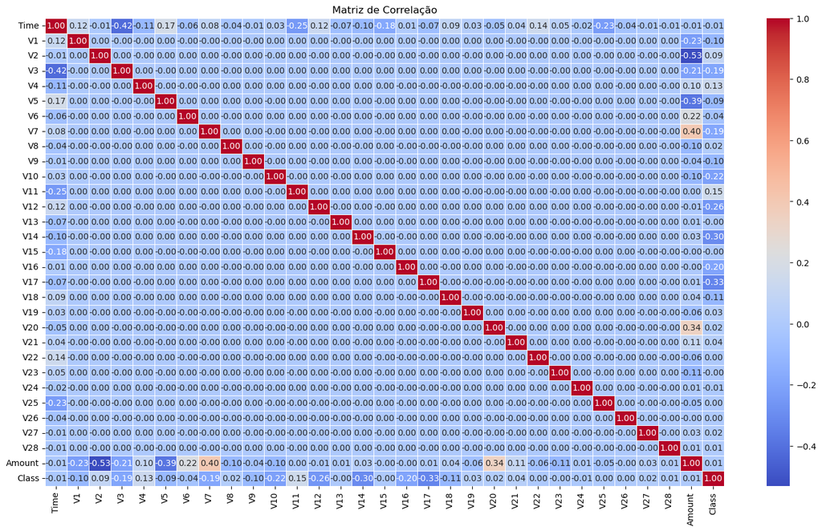

```python
plt.figure(figsize=(18, 10))
sns.heatmap(df_original.corr(), annot=True, cmap='coolwarm', fmt=".2f", linewidths=0.5)
plt.title('Matriz de Correlação')
plt.show()
```

# Split nos dados originais

```python
X = df_original.drop(columns=['Class'], axis=1)
y = df_original['Class']
```

```python
X_train_original, X_test_original, y_train_original, y_test_original = train_test_split(X, y, test_size=0.2, random_state=21)
```

#### Validando as distribuições

```python
print('Describe de treino:')
display(X_train_original.describe())

print('\nDescribe de teste:')
display(X_test_original.describe())

print('\nDistribuição de fraude na base de treino:')
display(y_train_original.to_frame()['Class'].value_counts())
display(y_train_original.to_frame()['Class'].value_counts(1))

print('\nDistribuição de fraude na base de teste:')
display(y_test_original.to_frame()['Class'].value_counts())
display(y_test_original.to_frame()['Class'].value_counts(1))
```

```
Describe de treino:
```

|  | Time | V1 | V2 | V3 | V4 | V5 | V6 | V7 | V8 | V9 | ... | V20 | V21 | V22 | V23 | V24 | V25 | V26 | V27 | V28 | Amount |
| --- | --- | --- | --- | --- | --- | --- | --- | --- | --- | --- | --- | --- | --- | --- | --- | --- | --- | --- | --- | --- | --- |
| count | 227845.000000 | 227845.000000 | 227845.000000 | 227845.000000 | 227845.000000 | 227845.000000 | 227845.000000 | 227845.000000 | 227845.000000 | 227845.000000 | ... | 227845.000000 | 227845.000000 | 227845.000000 | 227845.000000 | 227845.000000 | 227845.000000 | 227845.000000 | 227845.000000 | 227845.000000 | 227845.000000 |
| mean | 94799.020676 | 0.000174 | -0.001365 | -0.003386 | 0.000190 | -0.001483 | -0.001034 | 0.000631 | 0.000670 | 0.001430 | ... | -0.000340 | 0.000432 | 0.000257 | 0.000195 | -0.000562 | 0.000228 | -0.000222 | 0.000013 | 0.000099 | 88.502064 |
| std | 47499.435070 | 1.971155 | 1.659895 | 1.523706 | 1.414941 | 1.388924 | 1.332236 | 1.246508 | 1.196834 | 1.099960 | ... | 0.780951 | 0.739792 | 0.725920 | 0.618714 | 0.605352 | 0.521667 | 0.482660 | 0.404577 | 0.337103 | 253.374134 |
| min | 0.000000 | -56.407510 | -72.715728 | -48.325589 | -5.600607 | -113.743307 | -26.160506 | -43.557242 | -73.216718 | -13.434066 | ... | -54.497720 | -34.830382 | -10.933144 | -36.666000 | -2.836627 | -8.696627 | -2.604551 | -9.895244 | -15.430084 | 0.000000 |
| 25% | 54207.000000 | -0.918277 | -0.599558 | -0.890923 | -0.846347 | -0.692015 | -0.768632 | -0.554119 | -0.208743 | -0.641823 | ... | -0.211975 | -0.228295 | -0.541723 | -0.161636 | -0.355073 | -0.317322 | -0.327169 | -0.070836 | -0.052863 | 5.550000 |
| 50% | 84640.000000 | 0.023214 | 0.063697 | 0.178479 | -0.020248 | -0.053146 | -0.274135 | 0.040140 | 0.022464 | -0.049549 | ... | -0.062511 | -0.029427 | 0.006495 | -0.010720 | 0.040768 | 0.016919 | -0.052481 | 0.001430 | 0.011195 | 22.000000 |
| 75% | 139341.000000 | 1.316427 | 0.801844 | 1.025052 | 0.741196 | 0.612317 | 0.398258 | 0.570453 | 0.326785 | 0.597619 | ... | 0.132858 | 0.186852 | 0.529203 | 0.147814 | 0.438815 | 0.351273 | 0.240843 | 0.090744 | 0.078089 | 77.050000 |
| max | 172792.000000 | 2.454930 | 22.057729 | 4.226108 | 16.875344 | 34.801666 | 73.301626 | 120.589494 | 20.007208 | 10.392889 | ... | 39.420904 | 27.202839 | 10.503090 | 22.528412 | 4.584549 | 7.519589 | 3.517346 | 31.612198 | 33.847808 | 25691.160000 |

8 rows × 30 columns

```
Describe de teste:
```

|  | Time | V1 | V2 | V3 | V4 | V5 | V6 | V7 | V8 | V9 | ... | V20 | V21 | V22 | V23 | V24 | V25 | V26 | V27 | V28 | Amount |
| --- | --- | --- | --- | --- | --- | --- | --- | --- | --- | --- | --- | --- | --- | --- | --- | --- | --- | --- | --- | --- | --- |
| count | 56962.000000 | 56962.000000 | 56962.000000 | 56962.000000 | 56962.000000 | 56962.000000 | 56962.000000 | 56962.000000 | 56962.000000 | 56962.000000 | ... | 56962.000000 | 56962.000000 | 56962.000000 | 56962.000000 | 56962.000000 | 56962.000000 | 56962.000000 | 56962.000000 | 56962.000000 | 56962.000000 |
| mean | 94873.214389 | -0.000696 | 0.005461 | 0.013544 | -0.000759 | 0.005933 | 0.004136 | -0.002523 | -0.002681 | -0.005718 | ... | 0.001361 | -0.001727 | -0.001029 | -0.000780 | 0.002247 | -0.000913 | 0.000889 | -0.000051 | -0.000398 | 87.739847 |
| std | 47443.333461 | 1.908064 | 1.616511 | 1.486015 | 1.419584 | 1.344975 | 1.332416 | 1.198706 | 1.184385 | 1.093296 | ... | 0.729451 | 0.713068 | 0.724833 | 0.646939 | 0.606827 | 0.519724 | 0.480492 | 0.399836 | 0.300371 | 236.658343 |
| min | 7.000000 | -35.274010 | -40.978852 | -25.390229 | -5.683171 | -32.092129 | -17.574835 | -37.060311 | -50.688419 | -11.126624 | ... | -23.646890 | -22.757540 | -7.417140 | -44.807735 | -2.824849 | -10.295397 | -2.068561 | -22.565679 | -11.710896 | 0.000000 |
| 25% | 54187.750000 | -0.927959 | -0.593680 | -0.887022 | -0.856560 | -0.689161 | -0.767067 | -0.553645 | -0.208363 | -0.647741 | ... | -0.210603 | -0.228883 | -0.545206 | -0.162599 | -0.352707 | -0.316404 | -0.326273 | -0.070866 | -0.053396 | 5.710000 |
| 50% | 84954.500000 | -0.005976 | 0.073120 | 0.184959 | -0.018467 | -0.058519 | -0.274496 | 0.039913 | 0.021839 | -0.058020 | ... | -0.062382 | -0.029645 | 0.008421 | -0.012990 | 0.041594 | 0.015041 | -0.051164 | 0.001114 | 0.011424 | 22.075000 |
| 75% | 139248.000000 | 1.311509 | 0.811470 | 1.035517 | 0.751192 | 0.610188 | 0.400931 | 0.570343 | 0.330141 | 0.595253 | ... | 0.133647 | 0.184584 | 0.525947 | 0.146984 | 0.442354 | 0.348289 | 0.241437 | 0.092101 | 0.079004 | 77.695000 |
| max | 172785.000000 | 2.422508 | 19.167239 | 9.382558 | 13.143668 | 24.363532 | 21.393069 | 34.303177 | 15.374630 | 15.594995 | ... | 17.281859 | 16.666465 | 7.357255 | 18.946734 | 4.014444 | 5.852484 | 3.122747 | 8.932639 | 15.407019 | 7862.390000 |

8 rows × 30 columns

```
Distribuição de fraude na base de treino:
```

```
0    227462
1       383
Name: Class, dtype: int64
```

```
0    0.998319
1    0.001681
Name: Class, dtype: float64
```

```
Distribuição de fraude na base de teste:
```

```
0    56853
1      109
Name: Class, dtype: int64
```

```
0    0.998086
1    0.001914
Name: Class, dtype: float64
```

# Pré-processamento dos dados

#### Dados muito desbalanceados, e por isso serão aplicadas técnicas de balanceamento dos dados, como Oversampling e Undersampling.

#### A divisão entre dados de treino e teste deve ser feita antes da aplicação dos métodos de balanceamento, pois deseja-se testar o modelo com os dados originais.

#### Dados resultantes a partir dos métodos de Oversampling e Undersampling serão usados para definir qual modelo de classificação será aplicado.

## Escalonando as variáveis Time e Amount

- Somente essas variáveis não estão escalonadas, e como também serão usadas no treinamento do modelo, devem ser escalonadas.
- Ambas as variáveis possuem outliers, portanto não é recomendado aplicar o **StandardScaler()**, pois esse método é mais sensível a valores extremos.
- Uma boa solução para esse caso é a aplicação do método **RobustScaler()**, pois esse método utiliza os valores dos quartis e a mediana para ajustar os dados, não sendo influenciado pelos outliers.

```python
robust_scaler = RobustScaler()

# Criando as novas colunas de Time e Amount escalonadas nas bases de treino e teste
X_train_original['Time_scaled'] = robust_scaler.fit_transform(X_train_original['Time'].values.reshape(-1,1))
X_train_original['Amount_scaled'] = robust_scaler.fit_transform(X_train_original['Amount'].values.reshape(-1,1))

X_test_original['Time_scaled'] = robust_scaler.fit_transform(X_test_original['Time'].values.reshape(-1,1))
X_test_original['Amount_scaled'] = robust_scaler.fit_transform(X_test_original['Amount'].values.reshape(-1,1))

# Dropando as colunas não escalonadas
X_train_original = X_train_original.drop(columns=['Time', 'Amount'], axis=1)
X_test_original = X_test_original.drop(columns=['Time', 'Amount'], axis=1)

display(X_train_original)
display(X_test_original)
```

|  | V1 | V2 | V3 | V4 | V5 | V6 | V7 | V8 | V9 | V10 | ... | V21 | V22 | V23 | V24 | V25 | V26 | V27 | V28 | Time_scaled | Amount_scaled |
| --- | --- | --- | --- | --- | --- | --- | --- | --- | --- | --- | --- | --- | --- | --- | --- | --- | --- | --- | --- | --- | --- |
| 193580 | -0.799840 | 0.475496 | 0.945912 | 0.360518 | 0.849287 | -0.022402 | 0.946082 | -0.118777 | -0.132950 | -0.676126 | ... | -0.211023 | -0.301974 | 0.365713 | -0.575632 | -0.598082 | -1.066174 | 0.020482 | -0.058998 | 0.535133 | 0.704895 |
| 281512 | 1.606285 | -0.703248 | -0.394818 | 1.486715 | -0.788096 | -0.504766 | -0.227999 | -0.115749 | 0.882403 | 0.140248 | ... | 0.335594 | 0.713657 | -0.021267 | 0.040442 | -0.156591 | -0.583700 | 0.022747 | 0.002051 | 1.005345 | 2.323077 |
| 83404 | 1.281666 | 0.069899 | -0.068433 | -0.118893 | -0.178783 | -0.795593 | 0.142466 | -0.089915 | -0.153660 | 0.061727 | ... | -0.428059 | -1.371226 | 0.159838 | -0.059506 | 0.088230 | 0.631566 | -0.111973 | -0.012174 | -0.291376 | -0.189091 |
| 131366 | -0.247623 | 1.192310 | 0.733828 | -0.278547 | 0.832577 | -0.141225 | 0.796655 | -0.069621 | -0.526500 | -0.556700 | ... | -0.336441 | -0.825071 | -0.196949 | -1.027739 | 0.078189 | 0.153566 | 0.252257 | 0.087571 | -0.059494 | -0.209930 |
| 169064 | 2.109995 | 0.161872 | -1.950143 | 0.263848 | 0.775884 | -0.440883 | 0.182684 | -0.192945 | 0.477652 | -0.396496 | ... | -0.394579 | -1.001854 | 0.267583 | -0.111757 | -0.179542 | 0.213154 | -0.057794 | -0.036438 | 0.409590 | -0.289650 |
| ... | ... | ... | ... | ... | ... | ... | ... | ... | ... | ... | ... | ... | ... | ... | ... | ... | ... | ... | ... | ... | ... |
| 63856 | -0.043734 | -0.551311 | 1.569492 | -1.903996 | -1.151121 | -0.053123 | -0.499013 | 0.135010 | -2.136722 | 1.023972 | ... | -0.343545 | -0.583264 | -0.013246 | -0.049053 | -0.101647 | -0.366528 | 0.056215 | 0.013936 | -0.396375 | 0.111888 |
| 81968 | 1.140277 | -0.004898 | 0.072729 | 0.918752 | -0.129861 | -0.042564 | -0.127994 | 0.223495 | 0.153317 | 0.211107 | ... | 0.066068 | 0.058538 | -0.107472 | -0.369613 | 0.528540 | -0.288810 | 0.004279 | 0.001099 | -0.299023 | 0.036364 |
| 140036 | -0.754934 | -1.802975 | 0.866239 | -1.690596 | -3.007219 | 1.865597 | 0.741822 | 0.098395 | -1.798257 | 0.883077 | ... | 0.243652 | 1.268334 | 0.620800 | -0.282679 | -1.342805 | -0.245118 | 0.375048 | 0.193864 | -0.013367 | 7.153846 |
| 202552 | 2.051854 | -1.051863 | -2.279919 | -1.689759 | -0.048993 | -0.868512 | 0.092609 | -0.329633 | -0.646595 | 0.696963 | ... | -0.291720 | -0.583088 | 0.081217 | 0.366751 | -0.048046 | 0.634649 | -0.124288 | -0.065370 | 0.584291 | 1.234126 |
| 80841 | -0.496414 | 0.902277 | 1.383164 | 0.036025 | 0.031949 | -0.852536 | 0.523787 | 0.097163 | -0.586178 | -0.324452 | ... | -0.189754 | -0.588153 | 0.046176 | 0.469163 | -0.226233 | 0.043261 | 0.231659 | 0.092114 | -0.304955 | -0.149930 |

227845 rows × 30 columns

|  | V1 | V2 | V3 | V4 | V5 | V6 | V7 | V8 | V9 | V10 | ... | V21 | V22 | V23 | V24 | V25 | V26 | V27 | V28 | Time_scaled | Amount_scaled |
| --- | --- | --- | --- | --- | --- | --- | --- | --- | --- | --- | --- | --- | --- | --- | --- | --- | --- | --- | --- | --- | --- |
| 47499 | -4.907464 | -3.219507 | 1.976099 | 1.501927 | 0.089397 | 0.565583 | -0.662498 | -1.134323 | 3.474498 | 2.871005 | ... | -0.657012 | 1.063759 | -1.247375 | 0.293825 | -0.890266 | 1.099830 | -2.892506 | 0.858852 | -0.490494 | -0.224144 |
| 234614 | -2.343356 | -0.956658 | 2.558260 | 2.960781 | 2.619159 | -0.350503 | -1.083410 | 0.613996 | -1.031398 | 0.491581 | ... | 0.323283 | 0.187637 | -0.028306 | 0.540639 | 0.673751 | 0.089682 | -0.050855 | 0.112183 | 0.741751 | -0.306661 |
| 128968 | 1.225044 | 0.135849 | -0.232285 | -0.062222 | 0.981707 | 1.707754 | -0.353523 | 0.492103 | -0.320422 | 0.016330 | ... | -0.204101 | -0.753336 | 0.302322 | 3.267346 | 0.216635 | -0.042515 | -0.036323 | 0.036737 | -0.071108 | -0.288741 |
| 182186 | -1.461526 | 0.519650 | 1.588467 | -0.711261 | 0.042390 | -0.343000 | 0.685782 | -0.609369 | 1.327158 | 0.598965 | ... | 0.128365 | 0.903383 | -0.231424 | 0.037264 | -0.206913 | 0.505154 | -0.880873 | -0.177428 | 0.474293 | 0.059526 |
| 180179 | -2.388231 | -0.669561 | 2.824465 | 2.460076 | 3.215267 | -0.105877 | 0.246819 | -0.761898 | -0.643063 | 1.723674 | ... | -0.171976 | 0.428055 | -0.959228 | 0.534217 | 0.524773 | -0.117508 | -0.919279 | -0.473075 | 0.463924 | -0.296103 |
| ... | ... | ... | ... | ... | ... | ... | ... | ... | ... | ... | ... | ... | ... | ... | ... | ... | ... | ... | ... | ... | ... |
| 178816 | -0.565451 | -0.517422 | -0.123326 | -0.270570 | 1.198575 | -0.882160 | 0.781620 | -0.283067 | 0.226887 | 0.076829 | ... | 0.283158 | 1.240972 | 0.576767 | -0.488070 | -0.265460 | -0.146576 | -0.048595 | -0.237884 | 0.456612 | 0.054525 |
| 142058 | -0.448134 | 0.304089 | 1.586149 | -1.774752 | -0.989646 | 0.219339 | -1.465000 | -2.343226 | 1.088058 | -2.051250 | ... | -1.302742 | 0.297854 | -0.283698 | -0.032659 | 1.447444 | -0.670875 | 0.051334 | 0.163837 | -0.004579 | -0.292769 |
| 69294 | 1.257516 | 0.097742 | -0.299899 | 0.869715 | 0.715477 | 1.119524 | -0.116036 | 0.273541 | 0.227526 | 0.065064 | ... | -0.174101 | -0.300020 | -0.275479 | -1.704110 | 0.849335 | -0.220576 | 0.031867 | -0.014047 | -0.371495 | -0.292769 |
| 156894 | -0.460331 | 0.675030 | 1.784743 | -0.580025 | 0.876680 | 1.001622 | 0.331326 | 0.073187 | 1.418784 | -0.960307 | ... | -0.337706 | -0.634420 | -0.386967 | -0.475001 | 0.377240 | -0.712676 | -0.097320 | -0.160700 | 0.284322 | -0.161214 |
| 279021 | -0.283365 | -3.919257 | -3.961012 | 0.919706 | -0.377837 | -0.798445 | 2.460863 | -0.730901 | -0.140860 | -0.355759 | ... | 1.068077 | 0.352034 | -1.258735 | 0.896639 | 0.246736 | 0.275734 | -0.352874 | 0.120716 | 0.983297 | 17.002501 |

56962 rows × 30 columns

## Aplicando o Undersampling

- **Conceito**: Consiste em reduzir o número de registros da classe majoritária para o mesmo número de registros da classe minoritária, tornando assim os dados balanceados.

```python
# Unindo as bases de treino
df_train_merged = pd.concat([X_train_original, y_train_original], axis=1)
df_train_merged
```

|  | V1 | V2 | V3 | V4 | V5 | V6 | V7 | V8 | V9 | V10 | ... | V22 | V23 | V24 | V25 | V26 | V27 | V28 | Time_scaled | Amount_scaled | Class |
| --- | --- | --- | --- | --- | --- | --- | --- | --- | --- | --- | --- | --- | --- | --- | --- | --- | --- | --- | --- | --- | --- |
| 193580 | -0.799840 | 0.475496 | 0.945912 | 0.360518 | 0.849287 | -0.022402 | 0.946082 | -0.118777 | -0.132950 | -0.676126 | ... | -0.301974 | 0.365713 | -0.575632 | -0.598082 | -1.066174 | 0.020482 | -0.058998 | 0.535133 | 0.704895 | 0 |
| 281512 | 1.606285 | -0.703248 | -0.394818 | 1.486715 | -0.788096 | -0.504766 | -0.227999 | -0.115749 | 0.882403 | 0.140248 | ... | 0.713657 | -0.021267 | 0.040442 | -0.156591 | -0.583700 | 0.022747 | 0.002051 | 1.005345 | 2.323077 | 0 |
| 83404 | 1.281666 | 0.069899 | -0.068433 | -0.118893 | -0.178783 | -0.795593 | 0.142466 | -0.089915 | -0.153660 | 0.061727 | ... | -1.371226 | 0.159838 | -0.059506 | 0.088230 | 0.631566 | -0.111973 | -0.012174 | -0.291376 | -0.189091 | 0 |
| 131366 | -0.247623 | 1.192310 | 0.733828 | -0.278547 | 0.832577 | -0.141225 | 0.796655 | -0.069621 | -0.526500 | -0.556700 | ... | -0.825071 | -0.196949 | -1.027739 | 0.078189 | 0.153566 | 0.252257 | 0.087571 | -0.059494 | -0.209930 | 0 |
| 169064 | 2.109995 | 0.161872 | -1.950143 | 0.263848 | 0.775884 | -0.440883 | 0.182684 | -0.192945 | 0.477652 | -0.396496 | ... | -1.001854 | 0.267583 | -0.111757 | -0.179542 | 0.213154 | -0.057794 | -0.036438 | 0.409590 | -0.289650 | 0 |
| ... | ... | ... | ... | ... | ... | ... | ... | ... | ... | ... | ... | ... | ... | ... | ... | ... | ... | ... | ... | ... | ... |
| 63856 | -0.043734 | -0.551311 | 1.569492 | -1.903996 | -1.151121 | -0.053123 | -0.499013 | 0.135010 | -2.136722 | 1.023972 | ... | -0.583264 | -0.013246 | -0.049053 | -0.101647 | -0.366528 | 0.056215 | 0.013936 | -0.396375 | 0.111888 | 0 |
| 81968 | 1.140277 | -0.004898 | 0.072729 | 0.918752 | -0.129861 | -0.042564 | -0.127994 | 0.223495 | 0.153317 | 0.211107 | ... | 0.058538 | -0.107472 | -0.369613 | 0.528540 | -0.288810 | 0.004279 | 0.001099 | -0.299023 | 0.036364 | 0 |
| 140036 | -0.754934 | -1.802975 | 0.866239 | -1.690596 | -3.007219 | 1.865597 | 0.741822 | 0.098395 | -1.798257 | 0.883077 | ... | 1.268334 | 0.620800 | -0.282679 | -1.342805 | -0.245118 | 0.375048 | 0.193864 | -0.013367 | 7.153846 | 0 |
| 202552 | 2.051854 | -1.051863 | -2.279919 | -1.689759 | -0.048993 | -0.868512 | 0.092609 | -0.329633 | -0.646595 | 0.696963 | ... | -0.583088 | 0.081217 | 0.366751 | -0.048046 | 0.634649 | -0.124288 | -0.065370 | 0.584291 | 1.234126 | 0 |
| 80841 | -0.496414 | 0.902277 | 1.383164 | 0.036025 | 0.031949 | -0.852536 | 0.523787 | 0.097163 | -0.586178 | -0.324452 | ... | -0.588153 | 0.046176 | 0.469163 | -0.226233 | 0.043261 | 0.231659 | 0.092114 | -0.304955 | -0.149930 | 0 |

227845 rows × 31 columns

```python
# Dividindo os dados com base na classe das transações
classe_majoritaria = df_train_merged[df_train_merged['Class'] == 0]
classe_minoritaria = df_train_merged[df_train_merged['Class'] == 1]
```

```python
# Aplicando o Undersampling de forma randômica no dataframe da classe majoritária, com base no número de registros do dataframe da classe minotirária
classe_majoritaria_undersampled = resample(classe_majoritaria, replace=False, n_samples=len(classe_minoritaria), random_state=42)
classe_majoritaria_undersampled
```

|  | V1 | V2 | V3 | V4 | V5 | V6 | V7 | V8 | V9 | V10 | ... | V22 | V23 | V24 | V25 | V26 | V27 | V28 | Time_scaled | Amount_scaled | Class |
| --- | --- | --- | --- | --- | --- | --- | --- | --- | --- | --- | --- | --- | --- | --- | --- | --- | --- | --- | --- | --- | --- |
| 68840 | 1.154025 | -0.359806 | 1.093413 | 0.429951 | -1.239700 | -0.527943 | -0.636029 | 0.067462 | 1.027800 | -0.272498 | ... | -0.139390 | 0.035046 | 0.411535 | 0.120332 | 0.622361 | -0.022939 | 0.025590 | -0.369735 | 0.214545 | 0 |
| 61514 | -0.297973 | 0.351290 | 1.849945 | 1.638667 | 0.685234 | 0.642582 | 0.026520 | 0.118727 | -0.901637 | 0.723482 | ... | 0.604820 | 0.052452 | -0.221895 | -1.119664 | 0.925630 | -0.001380 | -0.032474 | -0.408368 | -0.236923 | 0 |
| 201755 | 2.110644 | 0.268234 | -2.179975 | 1.034858 | 0.959632 | -0.766823 | 0.649142 | -0.309518 | 0.070663 | 0.402032 | ... | 0.240494 | -0.008892 | 0.229223 | 0.494869 | -0.481817 | -0.042575 | -0.065100 | 0.580074 | -0.293706 | 0 |
| 66278 | -2.418556 | -1.656510 | 2.581566 | -0.555481 | 1.666799 | -0.470054 | -1.456528 | 0.759810 | 0.231895 | -0.578651 | ... | 0.610574 | 0.137288 | -0.204685 | 0.194957 | 1.094020 | 0.178317 | 0.142975 | -0.383736 | -0.048392 | 0 |
| 112829 | -0.849435 | 1.693047 | 1.018407 | 0.991312 | 1.520834 | 0.162477 | 1.402944 | -0.164761 | -1.678905 | 0.108561 | ... | 0.139724 | -0.439915 | -0.742381 | 0.514093 | -0.039313 | -0.236555 | 0.072259 | -0.138828 | -0.297063 | 0 |
| ... | ... | ... | ... | ... | ... | ... | ... | ... | ... | ... | ... | ... | ... | ... | ... | ... | ... | ... | ... | ... | ... |
| 60127 | 0.810782 | -0.742485 | -0.018558 | 0.132433 | -0.760161 | -1.028473 | 0.381905 | -0.354080 | 0.123121 | -0.316518 | ... | -0.003712 | -0.287888 | 0.456330 | 0.313603 | 1.076095 | -0.131116 | 0.045679 | -0.416626 | 3.332867 | 0 |
| 164271 | 2.012017 | -0.180197 | -1.028308 | 0.333356 | -0.232256 | -0.969360 | 0.007041 | -0.129667 | 0.446591 | 0.275221 | ... | -0.662015 | 0.352867 | 0.046517 | -0.379175 | 0.176481 | -0.081817 | -0.071598 | 0.375326 | -0.282657 | 0 |
| 255685 | -1.757812 | 1.268514 | -0.243560 | 0.834001 | 0.370026 | 0.082730 | 0.201648 | 0.651833 | 0.323763 | 1.018907 | ... | 0.851019 | -0.144330 | 0.699116 | 0.010938 | -0.428783 | 0.202376 | -0.080685 | 0.854054 | -0.167832 | 0 |
| 1232 | -0.194291 | 1.418104 | -0.121403 | 0.923643 | 0.281804 | -0.714429 | 0.606500 | 0.267974 | -0.778569 | -0.074793 | ... | 0.757402 | 0.085444 | 0.104186 | -0.743330 | -0.385085 | 0.335413 | 0.165982 | -0.983039 | -0.296643 | 0 |
| 243711 | 2.043561 | -0.274111 | -0.545477 | 0.005392 | -0.309407 | -0.386478 | -0.384668 | -0.149291 | 1.134972 | -0.254586 | ... | -0.405086 | 0.281361 | -0.636967 | -0.356891 | -0.248859 | 0.018335 | -0.039005 | 0.791705 | -0.167832 | 0 |

383 rows × 31 columns

```python
# Unindo os dataframes das diferentes classes
df_undersampled = pd.concat([classe_majoritaria_undersampled, classe_minoritaria])
display(df_undersampled)
display(df_undersampled['Class'].value_counts())
```

|  | V1 | V2 | V3 | V4 | V5 | V6 | V7 | V8 | V9 | V10 | ... | V22 | V23 | V24 | V25 | V26 | V27 | V28 | Time_scaled | Amount_scaled | Class |
| --- | --- | --- | --- | --- | --- | --- | --- | --- | --- | --- | --- | --- | --- | --- | --- | --- | --- | --- | --- | --- | --- |
| 68840 | 1.154025 | -0.359806 | 1.093413 | 0.429951 | -1.239700 | -0.527943 | -0.636029 | 0.067462 | 1.027800 | -0.272498 | ... | -0.139390 | 0.035046 | 0.411535 | 0.120332 | 0.622361 | -0.022939 | 0.025590 | -0.369735 | 0.214545 | 0 |
| 61514 | -0.297973 | 0.351290 | 1.849945 | 1.638667 | 0.685234 | 0.642582 | 0.026520 | 0.118727 | -0.901637 | 0.723482 | ... | 0.604820 | 0.052452 | -0.221895 | -1.119664 | 0.925630 | -0.001380 | -0.032474 | -0.408368 | -0.236923 | 0 |
| 201755 | 2.110644 | 0.268234 | -2.179975 | 1.034858 | 0.959632 | -0.766823 | 0.649142 | -0.309518 | 0.070663 | 0.402032 | ... | 0.240494 | -0.008892 | 0.229223 | 0.494869 | -0.481817 | -0.042575 | -0.065100 | 0.580074 | -0.293706 | 0 |
| 66278 | -2.418556 | -1.656510 | 2.581566 | -0.555481 | 1.666799 | -0.470054 | -1.456528 | 0.759810 | 0.231895 | -0.578651 | ... | 0.610574 | 0.137288 | -0.204685 | 0.194957 | 1.094020 | 0.178317 | 0.142975 | -0.383736 | -0.048392 | 0 |
| 112829 | -0.849435 | 1.693047 | 1.018407 | 0.991312 | 1.520834 | 0.162477 | 1.402944 | -0.164761 | -1.678905 | 0.108561 | ... | 0.139724 | -0.439915 | -0.742381 | 0.514093 | -0.039313 | -0.236555 | 0.072259 | -0.138828 | -0.297063 | 0 |
| ... | ... | ... | ... | ... | ... | ... | ... | ... | ... | ... | ... | ... | ... | ... | ... | ... | ... | ... | ... | ... | ... |
| 42945 | -13.680760 | 6.990389 | -13.770001 | 8.694897 | -11.426968 | -2.919845 | -14.594562 | 8.622905 | -8.090697 | -12.780634 | ... | 0.497599 | -0.509290 | 0.732503 | 0.280528 | 0.280037 | -1.406687 | -0.663643 | -0.508986 | -0.297063 | 1 |
| 57615 | -1.232804 | 2.244119 | -1.703826 | 1.492536 | -1.192985 | -1.686110 | -1.864612 | 0.856122 | -1.973535 | -3.942383 | ... | 0.165682 | -0.013754 | 0.474935 | -0.218725 | 0.302809 | 0.466031 | 0.250134 | -0.430592 | -0.297063 | 1 |
| 150663 | -5.839192 | 7.151532 | -12.816760 | 7.031115 | -9.651272 | -2.938427 | -11.543207 | 4.843627 | -3.494276 | -13.320789 | ... | 1.054865 | 0.530481 | 0.472670 | -0.275998 | 0.282435 | 0.104886 | 0.254417 | 0.108218 | 4.112727 | 1 |
| 6108 | -4.397974 | 1.358367 | -2.592844 | 2.679787 | -1.128131 | -1.706536 | -3.496197 | -0.248778 | -0.247768 | -4.801637 | ... | 0.176968 | -0.436207 | -0.053502 | 0.252405 | -0.657488 | -0.827136 | 0.849573 | -0.912139 | 0.517483 | 1 |
| 8972 | -4.064005 | 3.100935 | -1.188498 | 3.264633 | -1.903562 | 0.320351 | -0.954940 | -3.277535 | 2.820829 | 1.015113 | ... | -0.078845 | 0.193731 | 0.479496 | -0.506603 | -0.409863 | -3.036271 | -0.630605 | -0.848627 | 2.205035 | 1 |

766 rows × 31 columns

```
0    383
1    383
Name: Class, dtype: int64
```

```python
# Dividindo os registros já balanceados entre X e y
X_undersampled = df_undersampled.drop(columns=['Class'], axis=1)
y_undersampled = df_undersampled['Class']
```

## Aplicando o Oversampling

- **Conceito**: Consiste em aumentar o número de registros da classe minoritária, criando instâncias sintéticas com base nas instâncias já existentes da classe minoritária, tornando assim os dados balanceados.

#### O método SMOTE foi aplicado, pois cria registros sintéticos com base nos valores existentes da classe minoritária.

```python
# Criando o método, para aplicar somente para a classe minoritária
smote = SMOTE(sampling_strategy='minority', random_state=21)
X_oversampled, y_oversampled = smote.fit_resample(X_train_original, y_train_original)
```

```python
X_oversampled
```

|  | V1 | V2 | V3 | V4 | V5 | V6 | V7 | V8 | V9 | V10 | ... | V21 | V22 | V23 | V24 | V25 | V26 | V27 | V28 | Time_scaled | Amount_scaled |
| --- | --- | --- | --- | --- | --- | --- | --- | --- | --- | --- | --- | --- | --- | --- | --- | --- | --- | --- | --- | --- | --- |
| 0 | -0.799840 | 0.475496 | 0.945912 | 0.360518 | 0.849287 | -0.022402 | 0.946082 | -0.118777 | -0.132950 | -0.676126 | ... | -0.211023 | -0.301974 | 0.365713 | -0.575632 | -0.598082 | -1.066174 | 0.020482 | -0.058998 | 0.535133 | 0.704895 |
| 1 | 1.606285 | -0.703248 | -0.394818 | 1.486715 | -0.788096 | -0.504766 | -0.227999 | -0.115749 | 0.882403 | 0.140248 | ... | 0.335594 | 0.713657 | -0.021267 | 0.040442 | -0.156591 | -0.583700 | 0.022747 | 0.002051 | 1.005345 | 2.323077 |
| 2 | 1.281666 | 0.069899 | -0.068433 | -0.118893 | -0.178783 | -0.795593 | 0.142466 | -0.089915 | -0.153660 | 0.061727 | ... | -0.428059 | -1.371226 | 0.159838 | -0.059506 | 0.088230 | 0.631566 | -0.111973 | -0.012174 | -0.291376 | -0.189091 |
| 3 | -0.247623 | 1.192310 | 0.733828 | -0.278547 | 0.832577 | -0.141225 | 0.796655 | -0.069621 | -0.526500 | -0.556700 | ... | -0.336441 | -0.825071 | -0.196949 | -1.027739 | 0.078189 | 0.153566 | 0.252257 | 0.087571 | -0.059494 | -0.209930 |
| 4 | 2.109995 | 0.161872 | -1.950143 | 0.263848 | 0.775884 | -0.440883 | 0.182684 | -0.192945 | 0.477652 | -0.396496 | ... | -0.394579 | -1.001854 | 0.267583 | -0.111757 | -0.179542 | 0.213154 | -0.057794 | -0.036438 | 0.409590 | -0.289650 |
| ... | ... | ... | ... | ... | ... | ... | ... | ... | ... | ... | ... | ... | ... | ... | ... | ... | ... | ... | ... | ... | ... |
| 454919 | -3.991890 | 7.638717 | -13.239118 | 9.487160 | -3.028639 | -3.116221 | -9.277551 | 3.787909 | -5.984908 | -12.481804 | ... | 1.867388 | 0.039730 | -0.005285 | -1.193885 | 0.309492 | 0.620309 | 1.758245 | 0.799006 | -0.842056 | -0.293706 |
| 454920 | -3.406233 | 4.762496 | -8.832773 | 5.861748 | -4.989291 | -3.996457 | -9.561903 | 2.289039 | -3.484404 | -12.968203 | ... | 2.137093 | 0.584988 | -0.155884 | 0.430295 | 0.244165 | -0.206568 | 1.945475 | 0.985656 | 0.107176 | -0.297065 |
| 454921 | -5.908505 | 3.517956 | -6.115408 | 2.947817 | -2.192448 | -1.792948 | -4.181312 | 0.371658 | -1.603796 | -4.318051 | ... | 1.688749 | 0.229929 | 0.187394 | 0.815977 | -0.503573 | 0.372799 | -1.976511 | 1.478033 | 0.790481 | -0.007214 |
| 454922 | -3.408834 | 7.068453 | -12.271033 | 9.250790 | -2.395075 | -3.011166 | -8.569481 | 3.113141 | -6.043548 | -12.696984 | ... | 1.805505 | 0.004375 | -0.213528 | -1.188233 | 0.492257 | 0.615049 | 1.901056 | 0.843547 | -0.853387 | -0.293706 |
| 454923 | -2.271696 | 3.303448 | -1.702260 | 1.103686 | 0.403484 | 1.713068 | -2.554233 | -9.026292 | 2.714446 | -0.123169 | ... | 8.519251 | -1.992894 | 1.204436 | -0.340628 | -0.848678 | -0.548045 | -0.086632 | -0.104056 | 0.330388 | -0.204389 |

454924 rows × 30 columns

```python
y_oversampled.to_frame()['Class'].value_counts()
```

```
0    227462
1    227462
Name: Class, dtype: int64
```

# Seleção de modelos

#### Agora que os dados já estão balanceados pela aplicação dos métodos Undersampling e Oversampling, a etapa de seleção dos dados pode ser aplicada.

#### A Validação Cruzada Estratificada será aplicada nos dados de Undersampling, para avaliar qual dos classificadores escolhidos é o que obtém melhor performance com dados balanceados. Por questão de processamento, essa validação não será feita nos dados de Oversampling.

```python
# Criando a instância do tipo StratifiedKFold()
validacao_cruzada_estratificada = StratifiedKFold(n_splits=10)

# Lista de algoritmos de classificação
algoritmos_classificacao = [LogisticRegression(), SVC(), GaussianNB(), RandomForestClassifier(),
                            GradientBoostingClassifier(), CatBoostClassifier(verbose = False,  allow_writing_files=False), XGBClassifier(), LGBMClassifier()]
```

## Avaliando classificadores com dados do Undersampling

```python
# Lista para armazenar os resultados obtidos
resultados_algoritmos_undersampling = []

# Loop para avaliar cada algoritmo, e armazenar seus resultados em uma lista
for classificador in algoritmos_classificacao:
    resultados_algoritmos_undersampling.append(cross_val_score(classificador, X_undersampled, y = y_undersampled, scoring = "accuracy", cv = validacao_cruzada_estratificada, n_jobs=5))

# Listas para armazenar as médias da acurácia e os desvios padrões
cv_means_undersampling = []
cv_std_undersampling = []

# Armazenando os resultados em cada uma das listas
for resultado in resultados_algoritmos_undersampling:
    cv_means_undersampling.append(resultado.mean())
    cv_std_undersampling.append(resultado.std())

# Criando um Dataframe com os resultados obtidos
df_result_undersampling = pd.DataFrame({"MediaCV":cv_means_undersampling, "DesvioPadraoCV": cv_std_undersampling,
                                        "Algoritmo":["LogisticRegression","SVC", "GaussianNB", "RandomForest",
                                                     "GradientBoosting", "CatBoostClassifier", "XGBClassifier",
                                                     "LGBMClassifier"]})

df_result_undersampling.sort_values(by='MediaCV', ascending=False)
```

|  | MediaCV | DesvioPadraoCV | Algoritmo |
| --- | --- | --- | --- |
| 5 | 0.942618 | 0.022690 | CatBoostClassifier |
| 7 | 0.942601 | 0.018541 | LGBMClassifier |
| 0 | 0.941302 | 0.024250 | LogisticRegression |
| 6 | 0.937389 | 0.020796 | XGBClassifier |
| 3 | 0.932177 | 0.021544 | RandomForest |
| 1 | 0.932160 | 0.015009 | SVC |
| 4 | 0.925649 | 0.020063 | GradientBoosting |
| 2 | 0.912577 | 0.026596 | GaussianNB |

# Treinando o modelo LightGBM Classifier

#### Nesta etapa, o modelo LightGBM será treinado e validado com base nas etapas a seguir:

1 - Utilizando dados da aplicação do Undersampling

2 - Utilizando dados da aplicação do Oversampling

3 - Validando seu melhor resultado com os dados originais

# Dados do Undersampling

### Split nos dados

```python
X_train_undersampled, X_test_undersampled, y_train_undersampled, y_test_undersampled = train_test_split(X_undersampled, y_undersampled, test_size=0.2, random_state=21)

print('Describe de treino:')
display(X_train_undersampled.describe())

print('\nDescribe de teste:')
display(X_test_undersampled.describe())

print('\nDistribuição de fraude na base de treino:')
display(y_train_undersampled.to_frame()['Class'].value_counts())
display(y_train_undersampled.to_frame()['Class'].value_counts(1))

print('\nDistribuição de fraude na base de teste:')
display(y_test_undersampled.to_frame()['Class'].value_counts())
display(y_test_undersampled.to_frame()['Class'].value_counts(1))
```

```
Describe de treino:
```

|  | V1 | V2 | V3 | V4 | V5 | V6 | V7 | V8 | V9 | V10 | ... | V21 | V22 | V23 | V24 | V25 | V26 | V27 | V28 | Time_scaled | Amount_scaled |
| --- | --- | --- | --- | --- | --- | --- | --- | --- | --- | --- | --- | --- | --- | --- | --- | --- | --- | --- | --- | --- | --- |
| count | 612.000000 | 612.000000 | 612.000000 | 612.000000 | 612.000000 | 612.000000 | 612.000000 | 612.000000 | 612.000000 | 612.000000 | ... | 612.000000 | 612.000000 | 612.000000 | 612.000000 | 612.000000 | 612.000000 | 612.000000 | 612.000000 | 612.000000 | 612.000000 |
| mean | -2.139180 | 1.712597 | -3.300969 | 2.197681 | -1.383054 | -0.642261 | -2.631275 | 0.171444 | -1.204045 | -2.699635 | ... | 0.534399 | -0.041808 | 0.039245 | -0.055013 | 0.021896 | 0.016167 | 0.101054 | 0.048531 | 0.049127 | 1.018098 |
| std | 5.128373 | 3.468211 | 5.790388 | 3.091559 | 3.918308 | 1.768271 | 5.470968 | 5.177004 | 2.208552 | 4.312329 | ... | 3.147286 | 1.262770 | 1.063030 | 0.566786 | 0.659983 | 0.478604 | 0.934868 | 0.410894 | 0.557564 | 2.786663 |
| min | -30.552380 | -7.449015 | -31.103685 | -3.679228 | -22.105532 | -6.406267 | -43.557242 | -41.044261 | -13.320155 | -24.588262 | ... | -22.797604 | -8.887017 | -15.981649 | -2.096524 | -3.536716 | -1.380614 | -7.263482 | -1.869290 | -0.989381 | -0.307692 |
| 25% | -2.599443 | -0.219207 | -5.118062 | -0.142603 | -1.851255 | -1.572363 | -3.031843 | -0.229829 | -2.294145 | -4.518809 | ... | -0.154015 | -0.549141 | -0.233307 | -0.402046 | -0.326053 | -0.313241 | -0.064591 | -0.054284 | -0.420161 | -0.280000 |
| 50% | -0.793751 | 0.915917 | -1.467593 | 1.295292 | -0.383103 | -0.650664 | -0.697236 | 0.228692 | -0.661950 | -0.819017 | ... | 0.162164 | 0.033164 | -0.022820 | 0.001716 | 0.062677 | -0.011277 | 0.050111 | 0.034968 | -0.005715 | -0.045455 |
| 75% | 1.002407 | 2.608072 | 0.270655 | 4.097316 | 0.571255 | 0.152826 | 0.299879 | 0.860635 | 0.212117 | 0.008943 | ... | 0.714349 | 0.583581 | 0.227009 | 0.377555 | 0.403993 | 0.319144 | 0.462040 | 0.212081 | 0.565837 | 1.090769 |
| max | 2.304316 | 22.057729 | 3.236927 | 12.114672 | 11.095089 | 6.474115 | 5.802537 | 20.007208 | 4.874550 | 5.455026 | ... | 27.202839 | 8.316275 | 5.466230 | 1.169203 | 2.208209 | 1.524942 | 2.706566 | 1.521218 | 1.023375 | 29.424755 |

8 rows × 30 columns

```
Describe de teste:
```

|  | V1 | V2 | V3 | V4 | V5 | V6 | V7 | V8 | V9 | V10 | ... | V21 | V22 | V23 | V24 | V25 | V26 | V27 | V28 | Time_scaled | Amount_scaled |
| --- | --- | --- | --- | --- | --- | --- | --- | --- | --- | --- | --- | --- | --- | --- | --- | --- | --- | --- | --- | --- | --- |
| count | 154.000000 | 154.000000 | 154.000000 | 154.000000 | 154.000000 | 154.000000 | 154.000000 | 154.000000 | 154.000000 | 154.000000 | ... | 154.000000 | 154.000000 | 154.000000 | 154.000000 | 154.000000 | 154.000000 | 154.000000 | 154.000000 | 154.000000 | 154.000000 |
| mean | -3.465037 | 2.531079 | -4.698957 | 2.692747 | -2.239051 | -0.831325 | -4.088755 | 0.200644 | -1.653478 | -3.529197 | ... | -0.116045 | 0.118390 | -0.033130 | -0.098518 | 0.081253 | 0.022328 | 0.080129 | 0.025482 | -0.004596 | 0.752141 |
| std | 7.313412 | 4.699177 | 8.063140 | 3.582612 | 5.544513 | 1.912784 | 7.351036 | 5.849888 | 2.739945 | 5.500280 | ... | 2.758646 | 1.292117 | 0.800247 | 0.546676 | 0.737488 | 0.482453 | 1.271803 | 0.481006 | 0.553525 | 2.332636 |
| min | -29.200329 | -8.402154 | -30.177317 | -2.525992 | -21.225810 | -5.773192 | -41.506796 | -38.987263 | -13.434066 | -24.403185 | ... | -21.453736 | -2.454964 | -4.908301 | -1.544331 | -2.501833 | -1.054397 | -7.263482 | -1.552593 | -0.983039 | -0.307692 |
| 25% | -3.883364 | 0.064202 | -5.357303 | -0.091302 | -1.936381 | -1.883724 | -4.571700 | -0.288809 | -2.570676 | -6.017646 | ... | -0.310452 | -0.594326 | -0.261245 | -0.446803 | -0.275254 | -0.292187 | -0.049951 | -0.056428 | -0.487335 | -0.293706 |
| 50% | -0.715584 | 0.957499 | -1.599712 | 1.639880 | -0.292976 | -0.642363 | -0.843994 | 0.092638 | -0.860739 | -0.786989 | ... | 0.140900 | 0.041874 | -0.066583 | -0.031501 | 0.074999 | 0.031588 | 0.058248 | 0.023517 | -0.044495 | -0.081189 |
| 75% | 1.064993 | 3.791366 | 0.120712 | 5.500780 | 0.596306 | 0.080708 | 0.215893 | 0.857853 | 0.091864 | -0.002775 | ... | 0.698665 | 0.718788 | 0.126102 | 0.254836 | 0.466652 | 0.311033 | 0.524831 | 0.232611 | 0.468561 | 0.674825 |
| max | 2.152914 | 21.467203 | 2.403048 | 11.906170 | 9.880564 | 6.065901 | 1.402944 | 19.168327 | 3.353525 | 5.097069 | ... | 10.005998 | 8.361985 | 4.909111 | 1.074587 | 2.103868 | 2.745261 | 2.262942 | 1.779364 | 1.012427 | 19.126713 |

8 rows × 30 columns

```
Distribuição de fraude na base de treino:
```

```
0    309
1    303
Name: Class, dtype: int64
```

```
0    0.504902
1    0.495098
Name: Class, dtype: float64
```

```
Distribuição de fraude na base de teste:
```

```
1    80
0    74
Name: Class, dtype: int64
```

```
1    0.519481
0    0.480519
Name: Class, dtype: float64
```

### Ajuste de Hiperparâmetros utilizando a biblioteca Optuna

- **Optuna** é uma biblioteca que permite criar "estudos" que vão testar uma série de hiperparâmetros para modelos de machine learning, e retornar os que obtiverem os melhores resultados.
- Essa biblioteca será útil para encontrar os melhores hiperparâmetros para o classificador.

```python
# Definindo a função que o Optuna irá utilizar para testar os hiperparâmetros
def objective(trial):
    # Definindo os hiperparâmetros da LightGBM
    parametros = {
        'n_estimators': trial.suggest_int('n_estimators', 20, 200), # Quantidade máxima de nós
        'num_leaves': trial.suggest_int('num_leaves', 2, 50), # Quantidade máxima de folhas
        'max_depth': trial.suggest_int('max_depth', 3, 50), # Profundidade máxima das árvores
        'learning_rate': trial.suggest_loguniform('learning_rate', 0.001, 0.2), # Taxa de aprendizado
        'subsample': trial.suggest_uniform('subsample', 0.6, 1.0), # Subsample usado para impedir overfitting
        'min_child_weight': trial.suggest_int('min_child_weight', 1, 20), # Quantidade mínima para criar um novo nó
        'lambda_l1': trial.suggest_loguniform('lambda_l1', 1e-6, 1.0), # Penalização Lasso nas árvores
        'lambda_l2': trial.suggest_loguniform('lambda_l2', 1e-6, 1.0), # Penalização Ridge nas árvores
    }

    # Criando o modelo LightGBM com os hiperparâmetros otimizados
    modelo = LGBMClassifier(**parametros, random_state=21)

    # Treinando o modelo nos dados já balanceados pelo Undersampling
    modelo.fit(X_train_undersampled, y_train_undersampled)

    # Previsões para a base de testes
    y_pred_undersampled = modelo.predict(X_test_undersampled)

    # Realiza o cálculo da métrica de Recall, que seria a métrica mais segura dadas as condições originais dos dados
    recall = recall_score(y_test_undersampled, y_pred_undersampled)

    return recall
```

```python
# Criando a instância do estudo
study = optuna.create_study(direction='maximize') # Maximizar a Recall
study.optimize(objective, n_trials=100)

# Selecionando os melhores parâmetros com base na Recall
melhores_hiperparametros_under = study.best_params
melhor_recall_under = study.best_value

print(f'\nMelhores hiperparâmetros: {melhores_hiperparametros_under}')
print(f'\nMelhor Recall: {melhor_recall_under}')
```

[output not shown]

[output not shown]

[output cut: 405 more lines]

[output not shown]

[output not shown]

[output cut: 15 more lines]

[output not shown]

[output cut: 196 more lines]

[output not shown]

[output not shown]

[output not shown]

[output cut: 293 more lines]

[output not shown]

[output not shown]

[output cut: 196 more lines]

[output not shown]

[output not shown]

[output cut: 85 more lines]

[output not shown]

[output not shown]

[output not shown]

[output not shown]

[output cut: 46 more lines]

[output not shown]

[output not shown]

[output cut: 52 more lines]

[output not shown]

[output not shown]

[output not shown]

[output cut: 94 more lines]

[output not shown]

[output not shown]

[output not shown]

[output cut: 99 more lines]

[output not shown]

[output not shown]

[output not shown]

[output cut: 82 more lines]

[output not shown]

[output not shown]

[output cut: 217 more lines]

[output not shown]

[output not shown]

[output cut: 177 more lines]

[output not shown]

[output not shown]

[output not shown]

[output cut: 143 more lines]

[output not shown]

[output not shown]

[output cut: 162 more lines]

[output not shown]

[output not shown]

[output cut: 182 more lines]

[output not shown]

[output not shown]

[output cut: 139 more lines]

[output not shown]

[output not shown]

[output cut: 226 more lines]

[output not shown]

[output not shown]

[output cut: 248 more lines]

[output not shown]

[output not shown]

[output cut: 128 more lines]

[output not shown]

[output not shown]

[output cut: 214 more lines]

[output not shown]

[output not shown]

[output cut: 110 more lines]

[output not shown]

[output not shown]

[output cut: 180 more lines]

[output not shown]

[output not shown]

[output cut: 231 more lines]

[output not shown]

[output not shown]

[output cut: 179 more lines]

[output not shown]

[output not shown]

[output not shown]

[output cut: 161 more lines]

[output not shown]

[output not shown]

[output cut: 123 more lines]

[output not shown]

[output not shown]

[output cut: 139 more lines]

[output not shown]

[output not shown]

[output cut: 206 more lines]

[output not shown]

[output not shown]

[output cut: 193 more lines]

[output not shown]

[output not shown]

[output cut: 205 more lines]

[output not shown]

[output not shown]

[output cut: 87 more lines]

[output not shown]

[output not shown]

[output cut: 204 more lines]

[output not shown]

[output not shown]

[output not shown]

[output cut: 92 more lines]

[output not shown]

[output not shown]

[output cut: 98 more lines]

[output not shown]

[output not shown]

[output not shown]

[output cut: 136 more lines]

[output not shown]

[output not shown]

[output cut: 67 more lines]

[output not shown]

[output not shown]

[output cut: 198 more lines]

[output not shown]

[output not shown]